# Notebook 2: Data Munging Techniques

## YOUR TURN

Create a histogram for each RCP of maximum temperature values in July.

Hint: the geom function for a histogram is `geom_histogram()`. [Solution](https://bit.ly/2JPsXzG):

# Count extreme heat days

An extreme heat day is generally identified when the maximum temperature exceeds a threshold. The threshold can be chosen based on historical patterns, or a biophysical process. For this example, we’ll select 105.

Let’s count the total number of days the temperature exceeded 105. We start by adding a logical column whether the temperature exceeded our threshold. We’ll also throw away the minimum temperature values.

```r
lrec_prj_hot_tbl <- lrec_prj_tempf_tbl %>%
  filter(cvar == "tasmax") %>%
  mutate(really_hot = (temp_f >= set_units(105, degF))) %>%
  select(-spag, -val, -month)

head(lrec_prj_hot_tbl)
```

| id | cvar | period | gcm | scenario | dt | temp_f | year | really_hot |
| --- | --- | --- | --- | --- | --- | --- | --- | --- |
| 1 | tasmax | day | HadGEM2-ES | rcp45 | 2040-01-01 | 56.92297 [degF] | 2040 | FALSE |
| 1 | tasmax | day | HadGEM2-ES | rcp45 | 2040-01-02 | 61.49372 [degF] | 2040 | FALSE |
| 1 | tasmax | day | HadGEM2-ES | rcp45 | 2040-01-03 | 63.75828 [degF] | 2040 | FALSE |
| 1 | tasmax | day | HadGEM2-ES | rcp45 | 2040-01-04 | 72.32619 [degF] | 2040 | FALSE |
| 1 | tasmax | day | HadGEM2-ES | rcp45 | 2040-01-05 | 64.21806 [degF] | 2040 | FALSE |
| 1 | tasmax | day | HadGEM2-ES | rcp45 | 2040-01-06 | 57.49673 [degF] | 2040 | FALSE |

We can count the number of extreme heat days with a simple expression:

```r
num_hot_days <- lrec_prj_hot_tbl %>%
  group_by(scenario, really_hot) %>%
  count()

num_hot_days
```

| scenario | really_hot | n |
| --- | --- | --- |
| rcp45 | FALSE | 28815 |
| rcp45 | TRUE | 1869 |
| rcp85 | FALSE | 28044 |
| rcp85 | TRUE | 2640 |

We can improve the readability of this table by making each scenario a separate column. This is an example of [pivoting](https://tidyr.tidyverse.org/articles/pivot.html), which you can handle using `tidyr::pivot_wider`.

```r
num_hot_days %>% pivot_wider(names_from = scenario, values_from = n)
```

| really_hot | rcp45 | rcp85 |
| --- | --- | --- |
| FALSE | 28815 | 28044 |
| TRUE | 1869 | 2640 |

## YOUR TURN

Count the number of extreme heat days using a threshold of 110 Fahrenheit. Compute the mean number of extreme heat days per month.

# Count Consecutive Extreme Heat Days

Sometimes what matters most is not just the number of extreme heat days, but the number of consecutive extreme heat days lasting *n* or more days (i.e., an extreme heat spell). We can identify consecutive extreme heat days by using `rle` (run-length encoding), which simply finds groups of repeating values in a vector (as a primitive form of compression). But we have to chop up our data into ‘runs’ (year + gcm + scenario):

```r
## Group the rows by temperature values by year, GCM, and scenario
temp_by_gcm_year_scenario <- lrec_prj_hot_tbl %>%
  select(year, gcm, scenario, dt, really_hot) %>%
  group_by(year, gcm, scenario)

## Split each group of rows into its own tibble
temp_by_gcm_lst <- temp_by_gcm_year_scenario %>% group_split()

## For each tibble, run the really_hot column through rle()
rle_lst <- lapply(temp_by_gcm_lst, function(x) x %>% pull(really_hot) %>% rle())

## Define the minimum heat spell length
spell_length <- 3

## Count up the number of runs of really_hot=TRUE lasting >= spell_length days
num_spells_vec <- sapply(rle_lst, function(x) sum( x$lengths[x$values] >= spell_length))

## Add the number of spells column to the grouping keys (year, gcm, scenario)
num_spells_tbl <- group_keys(temp_by_gcm_year_scenario) %>%
  mutate(num_heat_spells = num_spells_vec)

## View the avg number of heat spells per scenario
num_spells_tbl %>%
  group_by(scenario) %>%
  summarise(mean_heat_spells_per_year = mean(num_heat_spells))
```

| scenario | mean_heat_spells_per_year |
| --- | --- |
| rcp45 | 2.892857 |
| rcp85 | 3.952381 |

# Display a Trend Line and Ensemble Range

In this part we’ll see how to add trend lines and the range of values of the 32-GCM ensemble to a time series plot.

First, we fetch 20 years of annual data for LREC, 4 GCMs, and 2 scenarios. Note below how we can combine the API reqest, data fetching, and data munging in one expression.

```r
lrec_prj_year_tbl <-
  ca_loc_pt(coords = c(-119.060, 36.359), id = 1) %>%
  ca_period("year") %>%
  ca_gcm(gcms[1:4]) %>%
  ca_scenario(c("rcp45", "rcp85")) %>%
  ca_cvar(c("tasmin", "tasmax")) %>%
  ca_years(start = 2040, end = 2060)%>%
  ca_getvals_tbl() %>%
  mutate(temp_f = set_units(val, degF), year = year(dt)) %>%
  group_by(year, scenario) %>%
  summarise(mean_temp = mean(temp_f))
## backup: lrec_prj_year_tbl <- readRDS("data/lrec_prj_year_tbl.rds")

dim(lrec_prj_year_tbl)
```

```
[1] 42  3
```

```r
head(lrec_prj_year_tbl)
```

| year | scenario | mean_temp |
| --- | --- | --- |
| 2040 | rcp45 | 65.59725 [degF] |
| 2040 | rcp85 | 66.49020 [degF] |
| 2041 | rcp45 | 66.15981 [degF] |
| 2041 | rcp85 | 66.52310 [degF] |
| 2042 | rcp45 | 66.10237 [degF] |
| 2042 | rcp85 | 66.42000 [degF] |

ggplot can create various types of trend lines by simply adding `geom_smooth()` to your plot definition:

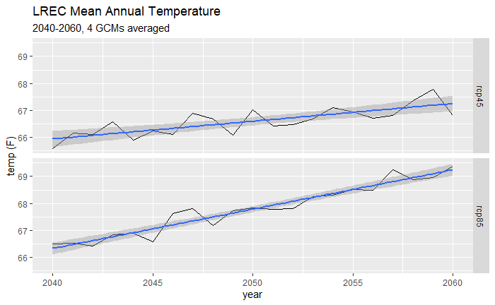

```r
ggplot(data = lrec_prj_year_tbl,
       aes(x = year, y = as.numeric(mean_temp))) +
  geom_line() +
  geom_smooth(method = "lm") +
  facet_grid(scenario ~ .) +
  labs(title = "LREC Mean Annual Temperature", x = "year", y = "temp (F)",
       subtitle = "2040-2060, 4 GCMs averaged")
```

The Cal-Adapt API also has climate data generated from an “ensemble GCM”, which includes all 32 GCMs in the CMIP5 project. We can show this in the background to get a feel for how close or how far off the 4GCMs we selected are from the main models.

First we grab the ensemble data:

```r
lrec_ens_year_tbl <-
  ca_loc_pt(coords = c(-119.060, 36.359), id = 1) %>%
  ca_period("year") %>%
  ca_gcm("ens32max") %>%
  ca_scenario(c("rcp45", "rcp85")) %>%
  ca_cvar(c("tasmin", "tasmax")) %>%
  ca_years(start = 2040, end = 2060)%>%
  ca_getvals_tbl() %>%
  mutate(temp_f = set_units(val, degF), year = year(dt)) %>%
  select(cvar, gcm, scenario, year, temp_f)
## backup: lrec_ens_year_tbl <- readRDS("data/lrec_ens_year_tbl.rds")

lrec_ens_year_tbl
```

| cvar | gcm | scenario | year | temp_f |
| --- | --- | --- | --- | --- |
| tasmin | ens32max | rcp45 | 2040 | 54.04477 [degF] |
| tasmin | ens32max | rcp45 | 2041 | 54.99943 [degF] |
| tasmin | ens32max | rcp45 | 2042 | 54.31311 [degF] |
| tasmin | ens32max | rcp45 | 2043 | 53.61378 [degF] |
| tasmin | ens32max | rcp45 | 2044 | 54.89720 [degF] |
| tasmin | ens32max | rcp45 | 2045 | 54.73455 [degF] |
| tasmin | ens32max | rcp45 | 2046 | 55.54770 [degF] |
| tasmin | ens32max | rcp45 | 2047 | 55.74573 [degF] |
| tasmin | ens32max | rcp45 | 2048 | 55.99721 [degF] |
| tasmin | ens32max | rcp45 | 2049 | 55.05029 [degF] |

[output cut: 74 more lines]

To display the min and max as a shaded background layer, we have to split them into different columns using `pivot_wider()`:

```r
lrec_ens_min_max <- lrec_ens_year_tbl %>%
  pivot_wider(names_from = cvar,
              values_from = temp_f,
              id_cols = c(year, scenario))

head(lrec_ens_min_max)
```

| year | scenario | tasmin | tasmax |
| --- | --- | --- | --- |
| 2040 | rcp45 | 54.04477 [degF] | 81.68742 [degF] |
| 2041 | rcp45 | 54.99943 [degF] | 82.64515 [degF] |
| 2042 | rcp45 | 54.31311 [degF] | 83.18716 [degF] |
| 2043 | rcp45 | 53.61378 [degF] | 82.43201 [degF] |
| 2044 | rcp45 | 54.89720 [degF] | 83.07263 [degF] |
| 2045 | rcp45 | 54.73455 [degF] | 83.00874 [degF] |

Now we can plot them as a `geom_ribbon()`:

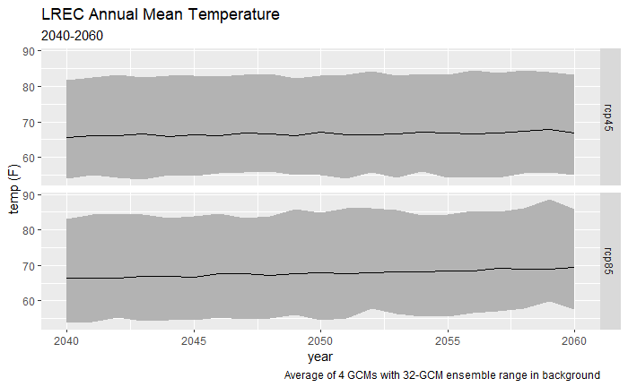

```r
my_plot <- ggplot() +
  geom_ribbon(data = lrec_ens_min_max,
              mapping = aes(x = year, ymin = as.numeric(tasmin), ymax = as.numeric(tasmax)),
              fill = "gray70") +
  geom_line(data = lrec_prj_year_tbl,
            mapping = aes(x = year, y = as.numeric(mean_temp))) +
  facet_grid(scenario ~ .) +
  labs(title = "LREC Annual Mean Temperature", x = "year", y = "temp (F)",
       subtitle = "2040-2060",
       caption = "Average of 4 GCMs with 32-GCM ensemble range in background")

my_plot
```